# lab_4 IDA

1. Взяти данi з роботи № 2 згiдно з варiантом. Представити данi графiчно.
2. Побудувати моделi нейронних мереж, використовуючи класи MLPClassifier або MLPRegressor, для класифiкацiї або регресiї згi дно з варiантом. Дослiдити вплив рiзних параметрiв MLPClassifier або MLPRegressor, згiдно з варiантом (!), на результат класифiкацiї/ре-гресiї:

• Побудувати рiзнi архiтектури нейронних мереж шляхом варiювання значень параметру hidden_layer_sizes. Порiвняти результати класи-фiкацiї/ регресiї, отриманi на основi рiзних архiтектур.

• Використати рiзнi методи розрахунку ваг (параметр solver); порiвняти результати, отриманi методами ‘lbfgs’, ‘sgd’ та ‘adam’.

• Використати рiзнi функцiї активацiї для скритого шару; дослiдити їх вплив на результат.

• Дослiдити вплив рiзних значень параметру регуляризацiї alpha класу MLPClassifier на результат класифiкацiї.

• Дослiдити вплив рiзних методiв визначення learning_rate на результат класифiкацiї (для solver=’sgd’).

• Розглянути рiзнi значення max_iter, дослiдити їх вплив на результат.

• Використати early_stopping=True.

• Використати warm_start=True.

• Вивести значення функцiї втрат на декiлькох перших i декiлькох остан-нiх iтерацiях - у кожному варiантi.

• Вивести значення середньої точностi класифiкацiї/регресiї на навчальнiй i тестовiй множинах, використовуючи score - у кожному варiантi.

1. Виконати прогнози на основi моделей нейронних мереж.
2. Зробити висновки про якiсть роботи моделей нейронних мереж на дослi джених даних. В задачах класифiкацiї для кожної навчальної ви-бiрки вибрати найкращу модель за критерiями якостi: • матриця неточностей (confusion matrix), • точнiсть (precision), • повнота (recall), • мiра F1 (F1 score), • ROC-крива, показник AUC.
3. Побудувати ансамблi моделей, використовуючи наступнi методи (згi дно з варiантом !):

   ```
    • VotingClassifier. Розглянути рiзнi значення параметрiв voting та weights.
   ```

4. Побудувати ансамблi AdaBoost, Bagging, Stacking, Voting (згiдно з варiантом !) на основi найпростiших моделей: • В якостi base_estimator / estimators використати одну/ декiль ка найпростiших моделей заданих за варiантом: дерев рiшень, svm, нейронних мереж тощо. Порiвняти значення мiр F1_score та AUC або R2 для ансамблiв та окремих моделей, якi утворюють ан-самбль (модель base_estimator / моделi estimators). Порiвняти декiль ка ансамблiв, якi утворенi на основi одних estimators i вiдрiзня ються значеннями параметрiв.

   • Побудувати графiки залежностi значень помилок класифiкацiї accuracy_score або zero_one_loss вiд значення n_estimators для до-слiджених ансамблiв та окремих моделей на однiй координатнiй вiсi.

   • В задачах класифiкацiї побудувати графiки залежностi значень мiри F1_score вiд значення n_estimators для дослiджених ан-самблiв та окремих моделей на однiй координатнiй вiсi. Ана-логiчнi графi ки побудувати для AUC. Графiки для окремих мо-делей, очевидно, будуть горизонтальними прямими. В задачах регресiї побудувати графiки залежностi значень R2 вiд значення n_estimators.

   • В задачах регресiї графiчно вiдобразити прогнози на основi base_estimator та на основi дослiджених ансамблiв, а також на вчальнi приклади на однiй координатнiй вiсi.

   • В задачах класифiкацiї вiдобразити границi рiшень decision boundaries на основi base_estimator / estimators та на основi до-слiджених ансамблiв.
5. Побудувати ансамблi на основi найкращої моделi / моделей нейронних ме-реж, знайдених на попереднiх етапах даної роботи, та найкращої моделi / мо-делей, знайдених у роботi №2. Порiвняти результати класифiкацiї, значення мiр F1_score та AUC для ансам-блiв та окремих моделей, якi утворюють цi ансамблi. В задачах регресiї порiвняти значення R2 для ансамблiв та окремих моделей, якi утворюють цi ансамблi.

#### 6 варіант

VotingClassifier. Розглянути рiзнi значення параметрiв voting та weights.

Дослiдити ансамблi, якi включають моделi нейронних мереж та моделi класифiкацiї, отриманi в роботi №2. В моделях нейронних мереж:

• Побудувати рiзнi архiтектури мереж шляхом варiювання значень параметру hidden_layer_sizes. Порiвняти результати класифiкацiї, отриманi на основi рiзних архiтектур.

• Розглянути рiзнi значення max_iter, дослiдити їх вплив на резуль-тат.

```python
from sklearn.datasets import make_moons
from sklearn.datasets import load_digits
from sklearn.model_selection import train_test_split
from sklearn.linear_model import LogisticRegression
from sklearn.preprocessing import StandardScaler
from sklearn import metrics as mt
from mlxtend.plotting import plot_decision_regions
import scikitplot.metrics as skplt
from sklearn.model_selection import GridSearchCV
import numpy as np
import pandas as pd
import matplotlib.pyplot as plt
import seaborn as sns
```

### 1. Взяти данi з роботи № 2 згiдно з варiантом. Представити данi графiчно.

```python
# create datasets
X_moons, y_moons = make_moons(n_samples=1500, noise=0.15)
digits_ = load_digits()
```

```python
def show_moons(X, y):
    df = pd.DataFrame(dict(x=X[:, 0], y=X[:, 1], label=y))
    colors = {0: 'red', 1: 'midnightblue'}
    fig, ax = plt.subplots()
    grouped = df.groupby('label')
    plt.title('Dataset of moons')
    for key, group in grouped:
        group.plot(ax=ax, kind='scatter', x='x', y='y', label='Class: '+str(key), color=colors[key])
    plt.show()


def show_digits(digits):
    fig = plt.figure(figsize=(6, 6))
    fig.subplots_adjust(left=0, right=1, bottom=0, top=1, hspace=0.05, wspace=0.05)
    plt.title('Dataset of digits')

    for i in range(64):
        ax = fig.add_subplot(8, 8, i + 1, xticks=[], yticks=[])
        ax.imshow(digits.images[i], cmap=plt.cm.binary, interpolation='nearest')
        ax.text(0, 7, str(digits.target[i]))
    plt.show()
```

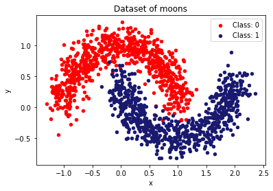

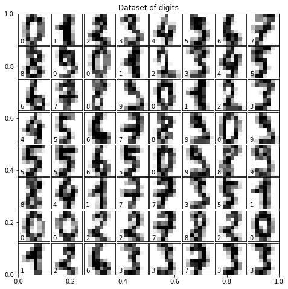

```python
# show datasets
show_moons(X_moons, y_moons)
show_digits(digits_)
```

```python
X_digits = digits_.data
y_digits = digits_.target
```

```python
# data preprocessing
X_moons = StandardScaler().fit_transform(X_moons)
X_digits = StandardScaler().fit_transform(X_digits)
```

```python
# create train and test samples
X_moons_train, X_moons_test, y_moons_train, y_moons_test = train_test_split(X_moons, y_moons, train_size=0.8)
X_digits_train, X_digits_test, y_digits_train, y_digits_test = train_test_split(X_digits, y_digits, train_size=0.8)
```

### 2. Побудувати моделi нейронних мереж, використовуючи класи MLPClassifier для класифiкацiї.

### + 3. Виконати прогнози на основi моделей нейронних мереж.

### + 4. Зробити висновки про якiсть роботи моделей нейронних мереж на дослi джених даних. В задачах класифiкацiї для кожної навчальної вибiрки вибрати найкращу модель за критерiями якостi.

```python
import warnings
from sklearn.neural_network import MLPClassifier
from sklearn.exceptions import ConvergenceWarning
from sklearn.model_selection import GridSearchCV
```

```python
def create_matrix(curr_model, x, y_test):
    y_predict = curr_model.predict(x)

    cm = mt.confusion_matrix(y_test, y_predict)
    score = curr_model.score(x, y_test)
    plt.figure(figsize=(9, 9))
    sns.heatmap(cm, annot=True, fmt=".3f", square=True)
    plt.ylabel("Actual label")
    plt.xlabel("Predicted label")
    plt.title(f"Accuracy Score:  {score}", size=15)
    plt.show()

    print('Precision-score: ', mt.precision_score(y_test, y_predict, average='micro'))
    print('Recall-score: ', mt.recall_score(y_test, y_predict, average='micro'))
    print('F1-score: ', mt.f1_score(y_test, y_predict, average='micro'))
```

```python
def estimate(curr_model, x, y_true, num_classes):
    create_matrix(curr_model, x, y_true)

    if num_classes == 2:
        pr_curve = mt.plot_precision_recall_curve(curr_model, x, y_true)
        pr_curve.ax_.set_title('Precision-Recall curve')
        plt.show()


        roc_curve_moons = mt.plot_roc_curve(curr_model, x, y_true)
        roc_curve_moons.ax_.set_title('ROC curve')
        plt.show()


    if num_classes > 2:
        y_probs = curr_model.predict_proba(x)
        skplt.plot_precision_recall(y_true, y_probs)
        plt.show()

        skplt.plot_roc(y_true, y_probs)
        plt.show()
```

```python
def create_models(X_train,y_train, X_test, y_test):

    hidden_layer_sizes = [(100,), (200,), (100, 50), (50, 100), (50, 100, 50), (100, 50, 100), (50, 50, 50, 50)]
    max_iter = [1000+i*100 for i in range(11)]
    scores = []

    for hld in hidden_layer_sizes:
        fig, (ax1, ax2) = plt.subplots(1, 2, figsize=(15, 4))
        scores.clear()
        for mi in max_iter:
            mlp = MLPClassifier(hidden_layer_sizes = hld, max_iter = mi, solver = 'sgd').fit(X_train, y_train)
            scores.append(mlp.score(X_test, y_test))

        ax1.set_title(f'hidden_layer_sizes: {hld}')
        ax1.plot(max_iter, scores)
        ax1.set_xlabel('Max iterations')
        ax1.set_ylabel("Model's score")

        ax2.set_title(f'Loss curve for hidden_layer_sizes: {hld}')
        ax2.plot(mlp.loss_curve_)
        plt.show()
```

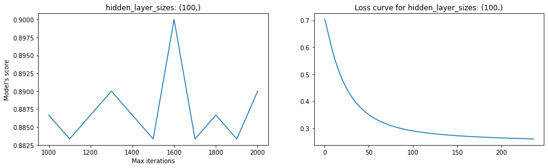

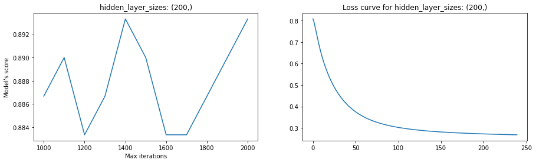

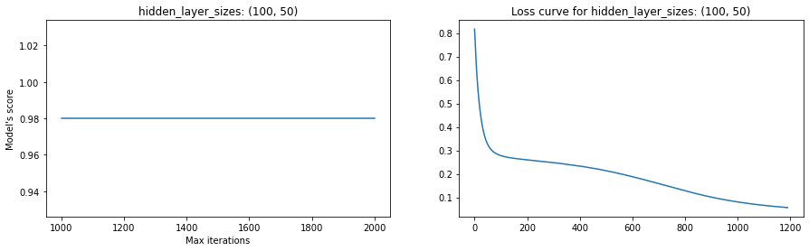

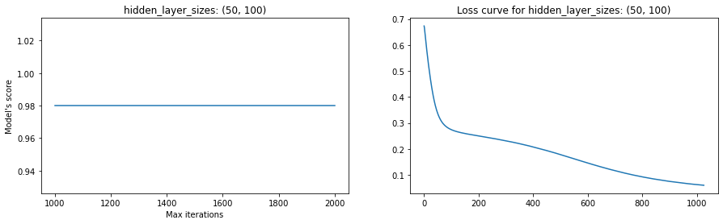

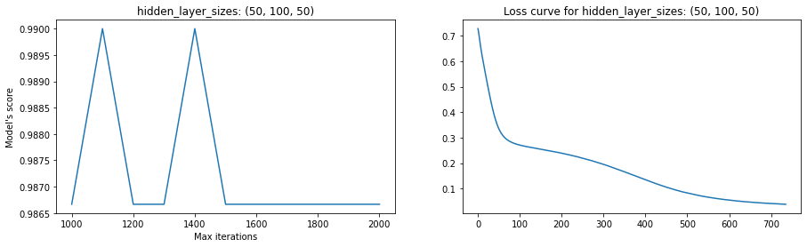

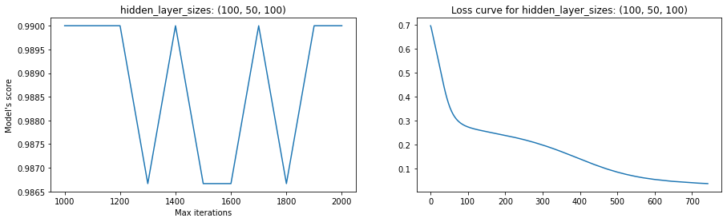

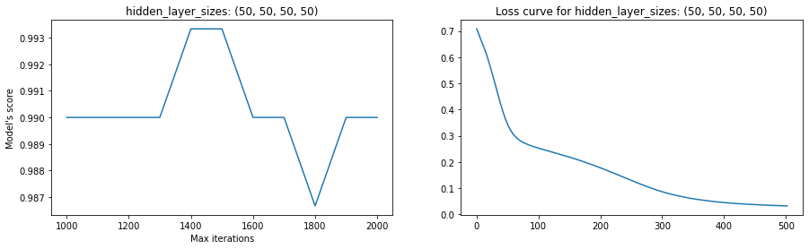

```python
create_models(X_moons_train, y_moons_train, X_moons_test, y_moons_test)
```

З графіків видно, що найкращі результати отримуються для моделей з трьома та чотирьма шарами. Однак врахувуючи відносну простоту та малий обсяг даасетів для подальшої роботи розглядатимуться тришарові.

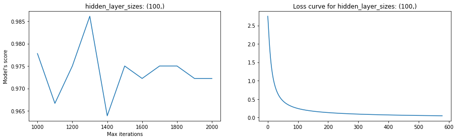

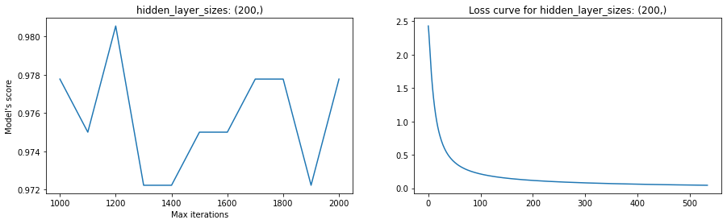

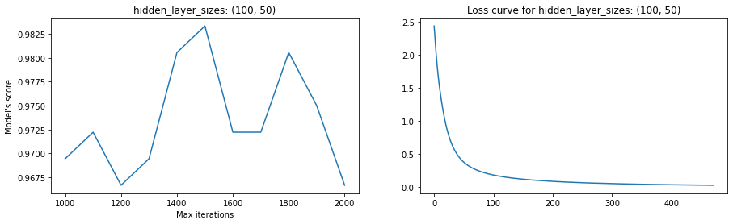

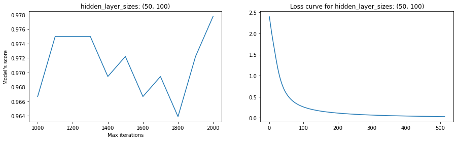

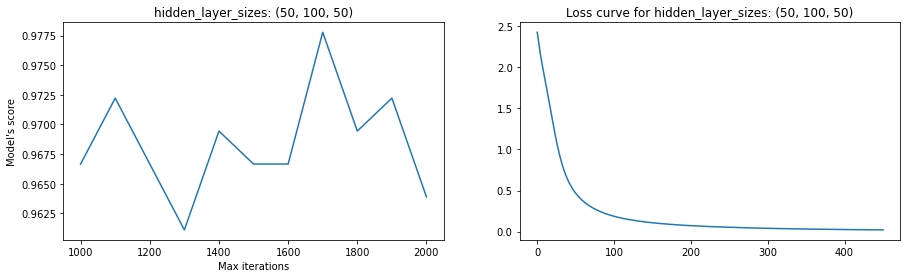

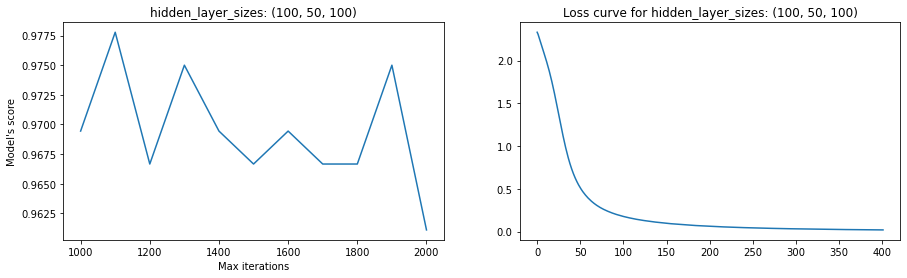

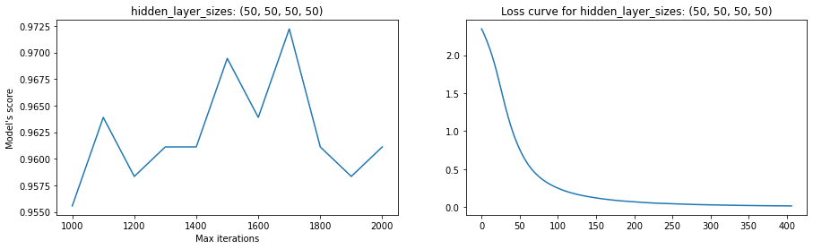

```python
create_models(X_digits_train, y_digits_train, X_digits_test, y_digits_test)
```

З графіків видно, що для датасету load_digits, на відмінну від make_moons краще працюють одношарові та двошарові персептрони, хоча різниця з іншими моделями є незначною

```python
parameters_m = [{"hidden_layer_sizes": [(50, 100, 50), (100, 50, 100)],
               "activation": ['identity', 'logistic', 'tanh', 'relu'],
               "max_iter": [10000],
               "solver": ['lbfgs', 'sgd', 'adam'],
               "alpha": [10**(i) for i in range(-3, 3)],
              }]
```

```python
best_mlp_moons = GridSearchCV(MLPClassifier(), param_grid = parameters_m)
best_mlp_moons.fit(X_moons_train, y_moons_train)
best_mlp_moons.best_params_
```

```
{'activation': 'tanh',
 'alpha': 0.01,
 'hidden_layer_sizes': (100, 50, 100),
 'max_iter': 10000,
 'solver': 'adam'}
```

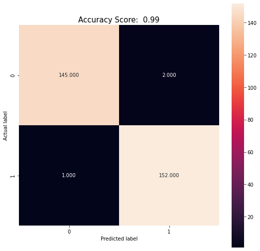

```
Precision-score:  0.99
Recall-score:  0.99
F1-score:  0.99
```

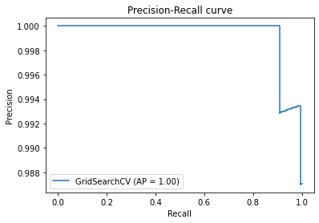

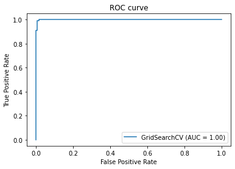

```python
estimate(best_mlp_moons, X_moons_test, y_moons_test, 2)
```

```python
parameters_d = [{"hidden_layer_sizes": [(200,), (100, 50)],
               "activation": ['identity', 'logistic', 'tanh', 'relu'],
               "max_iter": [10000],
               "solver": ['lbfgs', 'sgd', 'adam'],
               "alpha": [10**(i) for i in range(-3, 3)],
              }]
```

```python
best_mlp_digits = GridSearchCV(MLPClassifier(), param_grid = parameters_d)
best_mlp_digits.fit(X_digits_train, y_digits_train)
best_mlp_digits.best_params_
```

```
{'activation': 'relu',
 'alpha': 0.1,
 'hidden_layer_sizes': (100, 50),
 'max_iter': 10000,
 'solver': 'adam'}
```

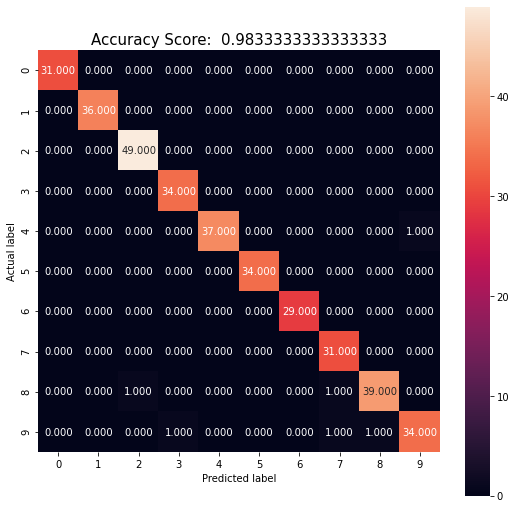

```
Precision-score:  0.9833333333333333
Recall-score:  0.9833333333333333
F1-score:  0.9833333333333333
```

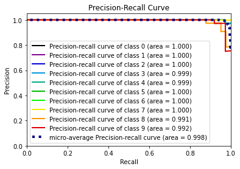

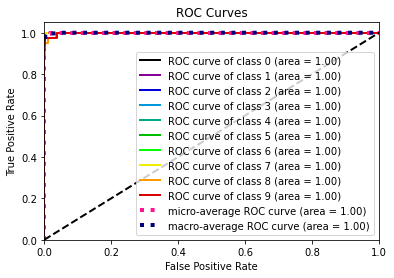

```python
estimate(best_mlp_digits, X_digits_test, y_digits_test, 10)
```

### 5. Побудувати ансамблi моделей, використовуючи наступнi методи: • VotingClassifier. Розглянути рiзнi значення параметрiв voting та weights.

### +6. Побудувати ансамбль Voting на основi найпростiших моделей (логістичної регресії, нейронних мереж)

```python
from sklearn.linear_model import LogisticRegression
from sklearn.ensemble import VotingClassifier
```

Параметр voting ансамблю Voting визначає спосіб "голосування" класифікаторів за віднесення і-го прикладу до певного класу. Можливі значення парметру: 'hard', 'soft'. При значенні параметра 'hard' рішення про остаточний передбачуваний клас деякого прикаду приймається на основі найбільшої кількості голосів за певний клас (тобто, якщо один з класифікаторів спрогнозував клас 0, а 2 інші - клас 1, то остаточним спрогнозованим класом буде 1). При значенні параметра 'soft' рішення про остаточний прогнозований клас приймається на основі найбільшої середньої апостеріорної ймовірності (тобто, якщо для класифікаторів 1, 2, 3 спрогнозовані ймовірності дорівнюють відповідно [0.2, 0.8], [0.8, 0.2], [0.3, 0.7], то остаточний спрогнозований клас буде 1)

При встановленні для параметру voting значення 'soft' можливо також встановити параметр weights, який визначає ступінь "довіри" до класифікатора. Якщо weights не встановлений, то за замовчуванням всі класифікатори рівноцінні і працюють так, як показано в попередньому прикладі.

##### Датасет make_moons:

```python
lg1 = LogisticRegression()
lg2 = LogisticRegression()
mlp1 = MLPClassifier(max_iter = 600)
mlp2 = MLPClassifier(max_iter = 600)

estimators_m = [('log_reg1', lg1),
                ('mlp1', mlp1),
                ('mlp2', mlp2)]
estimators_d = [('log_reg1', lg1),
                ('log_reg2', lg2),
                ('mlp2', mlp2)]

weights_m = [None, [0.2, 0.4, 0.4], [0.5, 0.25, 0.25]]
weights_d = [None, [0.2, 0.4, 0.4], [0.5, 0.25, 0.25]]
```

```python
def decision_regions(X, y, model):
    plot_decision_regions(X, y, clf=model)
    plt.xlabel('x1')
    plt.ylabel('x2')
    plt.title('decision regions')
    plt.show()
```

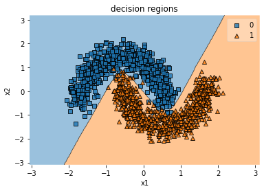

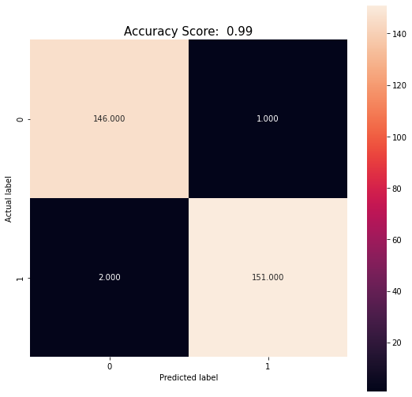

```
Precision-score:  0.99
Recall-score:  0.99
F1-score:  0.99
```

```python
ens_moons_hard = VotingClassifier(estimators = estimators_m,
                                  voting='hard').fit(X_moons_train, y_moons_train)
decision_regions(X_moons, y_moons, ens_moons_hard)
create_matrix(ens_moons_hard, X_moons_test, y_moons_test)
```